## Inspired by Julia Silge

We would like to try XGBoost on this dataset. XGBoost doesn’t require a lot of preprocessing of the data, yet it has a lot of hyperparameters to tune.

```r
# Get the Data

vb_matches <- readr::read_csv('https://raw.githubusercontent.com/rfordatascience/tidytuesday/master/data/2020/2020-05-19/vb_matches.csv', guess_max = 76000)
```

```r
vb_parsed <- vb_matches %>%
  transmute(
    circuit,
    gender,
    year,
    w_attacks = w_p1_tot_attacks + w_p2_tot_blocks,
    w_kills = w_p1_tot_kills + w_p2_tot_kills,
    w_errors = w_p1_tot_errors + w_p2_tot_errors,
    w_aces = w_p1_tot_aces + w_p2_tot_aces,
    w_serve_errors = w_p1_tot_serve_errors + w_p2_tot_serve_errors,
    w_blocks = w_p1_tot_blocks + w_p2_tot_blocks,
    w_digs = w_p1_tot_digs + w_p2_tot_digs,

    l_attacks = l_p1_tot_attacks + l_p2_tot_blocks,
    l_kills = l_p1_tot_kills + l_p2_tot_kills,
    l_errors = l_p1_tot_errors + l_p2_tot_errors,
    l_aces = l_p1_tot_aces + l_p2_tot_aces,
    l_serve_errors = l_p1_tot_serve_errors + l_p2_tot_serve_errors,
    l_blocks = l_p1_tot_blocks + l_p2_tot_blocks,
    l_digs = l_p1_tot_digs + l_p2_tot_digs
  ) %>%
  na.omit()

winners <- vb_parsed %>%
  select(circuit, gender, year,
         w_attacks:w_digs) %>%
  rename_at(vars(starts_with("w_")), list(~ str_remove_all(., "w_"))) %>%
  mutate(win = "win")

losers <- vb_parsed %>%
  select(circuit, gender, year,
         l_attacks:l_digs) %>%
  rename_at(vars(starts_with("l_")), list(~ str_remove_all(., "l_"))) %>%
  mutate(win = "lose")
```

```r
vb_df <- bind_rows(winners, losers) %>%
  mutate_if(is.character, factor)
```

We can plot exploratory boxplots to see which features that may be interesting for our models.

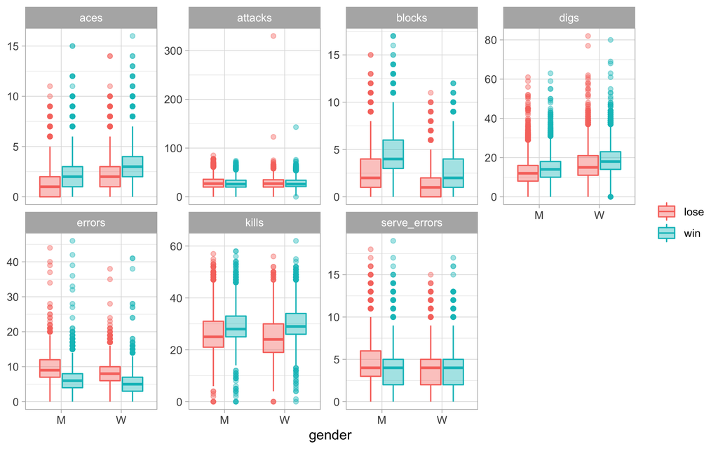

```r
vb_df %>%
  pivot_longer(attacks:digs, names_to = "stat", values_to = "value") %>%
  ggplot(aes(gender, value, fill = win, color = win)) +
  geom_boxplot(alpha = 0.4) +
  facet_wrap(~stat, scales = "free_y", nrow = 2) +
  labs(y = NULL, color = NULL, fill = NULL)
```

## Build a model

```r
library(tidymodels)

set.seed(123)
vb_split <- initial_split(vb_df, strata = win)
vb_train <- training(vb_split)
vb_test <- testing(vb_split)
```

```r
xgb_spec <- boost_tree(
  trees = 1000,
  tree_depth = tune(),
  min_n = tune(),
  loss_reduction = tune(),
  sample_size = tune(),
  mtry = tune(),
  learn_rate = tune()
) %>%
  set_engine("xgboost") %>%
  set_mode("classification")

xgb_spec
```

```
## Boosted Tree Model Specification (classification)
##
## Main Arguments:
##   mtry = tune()
##   trees = 1000
##   min_n = tune()
##   tree_depth = tune()
##   learn_rate = tune()
##   loss_reduction = tune()
##   sample_size = tune()
##
## Computational engine: xgboost
```

```r
xgb_grid <- grid_latin_hypercube(
  tree_depth(),
  min_n(),
  loss_reduction(),
  sample_size = sample_prop(),
  finalize(mtry(), vb_train),
  learn_rate(),
  size = 30 #can increase the size
)
xgb_grid
```

```
## # A tibble: 30 x 6
##    tree_depth min_n loss_reduction sample_size  mtry learn_rate
##         <int> <int>          <dbl>       <dbl> <int>      <dbl>
##  1         12    31       1.48e- 9     0.0817      9   6.92e- 3
##  2          8    20       6.66e- 9     0.0239      2   1.80e- 5
##  3          2     8       1.87e- 8     0.0204      6   1.89e- 3
##  4          7    29       6.13e- 1     0.0134      5   7.64e- 8
##  5          6     6       2.13e-10     0.0671      6   4.65e- 6
##  6          9     3       3.25e- 5     0.0415      9   4.92e- 9
##  7          3    24       1.43e+ 1     0.0791     10   1.34e- 9
##  8          2    16       1.21e- 3     0.00834    11   2.16e- 2
##  9          5    15       1.28e+ 0     0.0310      5   1.45e-10
## 10         11    38       2.07e- 2     0.00528     2   1.68e- 8
## # … with 20 more rows
```

```r
xgb_wf <- workflow() %>%
  add_formula(win ~ .) %>%
  add_model(xgb_spec)
xgb_wf
```

```
## ══ Workflow ═════════════════════════════════════════════════════════════════════════════════════════
## Preprocessor: Formula
## Model: boost_tree()
##
## ── Preprocessor ─────────────────────────────────────────────────────────────────────────────────────
## win ~ .
##
## ── Model ────────────────────────────────────────────────────────────────────────────────────────────
## Boosted Tree Model Specification (classification)
##
## Main Arguments:
##   mtry = tune()
##   trees = 1000
##   min_n = tune()
##   tree_depth = tune()
##   learn_rate = tune()
##   loss_reduction = tune()
##   sample_size = tune()
##
## Computational engine: xgboost
```

```r
set.seed(123)
vb_folds <- vfold_cv(vb_train, strata = win, v = 10)
vb_folds
```

```
## #  10-fold cross-validation using stratification
## # A tibble: 10 x 2
##    splits               id
##    <named list>         <chr>
##  1 <split [19.3K/2.1K]> Fold01
##  2 <split [19.3K/2.1K]> Fold02
##  3 <split [19.3K/2.1K]> Fold03
##  4 <split [19.3K/2.1K]> Fold04
##  5 <split [19.3K/2.1K]> Fold05
##  6 <split [19.3K/2.1K]> Fold06
##  7 <split [19.3K/2.1K]> Fold07
##  8 <split [19.3K/2.1K]> Fold08
##  9 <split [19.3K/2.1K]> Fold09
## 10 <split [19.4K/2.1K]> Fold10
```

```r
doParallel::registerDoParallel()

set.seed(234)
xgb_res <- tune_grid(
  xgb_wf,
  resamples = vb_folds,
  grid = xgb_grid,
  control = control_grid(save_pred = TRUE)
)
library(beepr)
beep("treasure")
```

## Explore results

We can plot roc-auc vs parameters to visualize how different values of each parameter affect roc-auc.

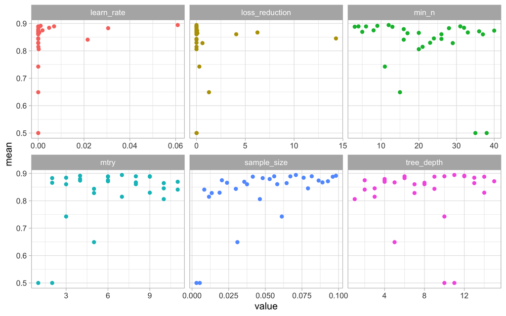

```r
xgb_res %>%
  collect_metrics() %>%
  filter(.metric == "roc_auc") %>%
  select(mean, mtry:sample_size) %>%
  pivot_longer(mtry:sample_size,
               names_to = "parameter",
               values_to = "value") %>%
  ggplot(aes(value, mean, color = parameter)) +
  geom_point(show.legend = FALSE) +
  facet_wrap(~ parameter, scales = "free_x")
```

```r
show_best(xgb_res, "roc_auc")
```

```
## # A tibble: 5 x 11
##    mtry min_n tree_depth learn_rate loss_reduction sample_size .metric
##   <int> <int>      <int>      <dbl>          <dbl>       <dbl> <chr>
## 1     7    12         11 0.0609     0.0000000859        0.0709 roc_auc
## 2     4     9         12 0.00106    0.0000000435        0.0982 roc_auc
## 3     9    31         12 0.00692    0.00000000148       0.0817 roc_auc
## 4     8     4         10 0.0000467  0.000154            0.0561 roc_auc
## 5     6     6          6 0.00000465 0.000000000213      0.0671 roc_auc
## # … with 4 more variables: .estimator <chr>, mean <dbl>, n <int>, std_err <dbl>
```

```r
best_auc <- select_best(xgb_res, "roc_auc")

xgb_final <- finalize_workflow(xgb_wf, best_auc)
xgb_final
```

```
## ══ Workflow ═════════════════════════════════════════════════════════════════════════════════════════
## Preprocessor: Formula
## Model: boost_tree()
##
## ── Preprocessor ─────────────────────────────────────────────────────────────────────────────────────
## win ~ .
##
## ── Model ────────────────────────────────────────────────────────────────────────────────────────────
## Boosted Tree Model Specification (classification)
##
## Main Arguments:
##   mtry = 7
##   trees = 1000
##   min_n = 12
##   tree_depth = 11
##   learn_rate = 0.060917735661538
##   loss_reduction = 8.59154112728595e-08
##   sample_size = 0.0708513490785845
##
## Computational engine: xgboost
```

Now, we can look at feature importance.

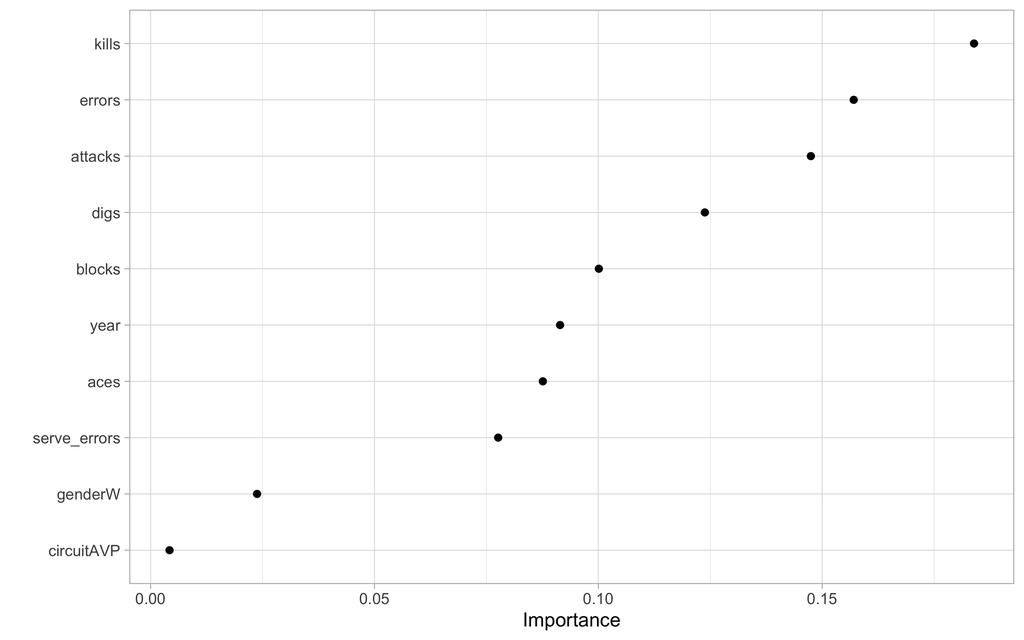

```r
library(vip)

xgb_final %>%
  fit(data = vb_train) %>%
  pull_workflow_fit() %>%
  vip(geom = "point")
```

Errors and Kills have the highest relative importance as compared to other features.

Finally, we can evaluate the performance of this xgboost model to our test data.

```r
final_res <- last_fit(xgb_final, vb_split)

final_res %>%
  collect_metrics()
```

```
## # A tibble: 2 x 3
##   .metric  .estimator .estimate
##   <chr>    <chr>          <dbl>
## 1 accuracy binary         0.808
## 2 roc_auc  binary         0.895
```

Since the difference between roc-auc for training and test set is not that high, we can safely assume that our model does not overfit our data.

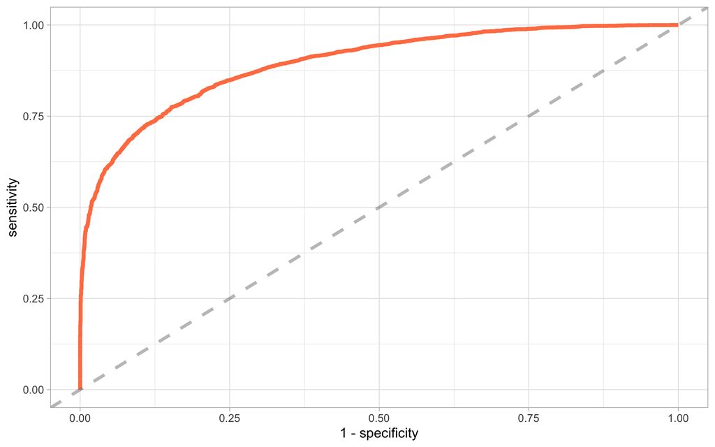

```r
final_res %>%
  collect_predictions() %>%
  roc_curve(win, .pred_win) %>%
  ggplot(aes(x = 1 - specificity, y = sensitivity)) +
  geom_line(size = 1.5, color = "coral") +
  geom_abline(
    lty = 2, alpha = 0.5,
    color = "gray50",
    size = 1.2
  )
```